# Project: U.S Gun Registration by State Compared with U.S Census Data

- Introduction
- Data Wrangling
- Exploratory Data Analysis
- Conclusions

## Introduction

> In this analysis of gun registration data vs U.S Census Beaureau data, the gun data was found on GitHub but originally extracted from the FBI's National Instant Criminal Background Check System (NCIS). The U.S Census data was found on census.gov.

> The census data provided is for the years 2015 and 2016, meaning that some attributes reflect observations from 2015 and others from 2016, for 50 states. The gun registration data has observations indexed by month from 1998 - 2017, for 55 states/territories.

> The attributes being used from the census data are going to be based on population demographics, employment, income and povery, and highest level of completed education by state. The attributes for the gun data will be based on the type of gun being registered and if the sale was private. The estimated sale of guns will be calculated by using this equation: (handgun check + long gun check + 2 *multple gun check)* 1.1 . This equation is suggested in the [Small Arms Survey](http://www.smallarmssurvey.org/fileadmin/docs/F-Working-papers/SAS-WP14-US-Firearms-Industry.pdf) by Jurgen Brauer, a professor at Georgia Regents University " As approximations go, one may then add ‘handgun’ checks, plus ‘long gun’ checks, plus two ‘multiple’ checks (at least one handgun and one long gun), and augment the resulting number by a factor of 1.1, termed here the multiple gun sales factor (MGSF)".

> The questions we will be posing are:
> 1. which states have the highest total gun sales?
> 2. Are gun sales growing or declining?
> 3. what are the characteristics of states with higher hand gun purchases and those with higher long gun purchases?
> 4. What are the relationships between various census data to private gun sales and regular gun sales?

> We will be answering questions 1 and 2 by analyzing only the gun dataset. For the questions 3,4 we will compare both data sets. For this we need to change the shape of the census data. And for the gun data we will aggregate and take the average values of each attribute for the years 2015 and 2016, because the census data attributes reflect both of those years.

## Data Wrangling

#### First I will be importing the libraries I will use for this step, then I will load both datasets from csv files into a dataframe. I will also be selecting the rows and columns to be used for each dataframe in this first step.

```python
import pandas as pd

# load gun dataframe
df_gun = pd.read_csv('gun-data.csv', usecols = [0,1,4,5,7,20,21])

# function used to select the row indexes for census data
def rows(index):
    if index in range(2,13) or index == 15 or index == 17 or index == 18:
        return True
    elif index in range(20,35)  or index in range (37,39) or index in range(40,48) or index == 49:
        return True
    elif index in range(51,86):
        return True
    else:
        return False

# load census dataframe
df_cen = pd.read_csv('u.s.-census-data.csv',skiprows = lambda x: rows(x))
```

### General Properties

#### Lets inspect the dataframes to see their data types, the shape of the data and some descriptive statistics of the attributes

```python
df_gun.info()
```

```
<class 'pandas.core.frame.DataFrame'>
RangeIndex: 12485 entries, 0 to 12484
Data columns (total 7 columns):
 #   Column                 Non-Null Count  Dtype
---  ------                 --------------  -----
 0   month                  12485 non-null  object
 1   state                  12485 non-null  object
 2   handgun                12465 non-null  float64
 3   long_gun               12466 non-null  float64
 4   multiple               12485 non-null  int64
 5   private_sale_handgun   2750 non-null   float64
 6   private_sale_long_gun  2750 non-null   float64
dtypes: float64(4), int64(1), object(2)
memory usage: 682.9+ KB
```

```python
df_gun.isnull().sum()
```

```
month                       0
state                       0
handgun                    20
long_gun                   19
multiple                    0
private_sale_handgun     9735
private_sale_long_gun    9735
dtype: int64
```

> Month should be converted to datetime and there looks to be some missing values for the gun data.

#### Lets print some rows to see if the data is structured properly for analysis

```python
df_gun.head()
```

|  | month | state | handgun | long_gun | multiple | private_sale_handgun | private_sale_long_gun |
| --- | --- | --- | --- | --- | --- | --- | --- |
| 0 | 2017-09 | Alabama | 5734.0 | 6320.0 | 317 | 9.0 | 16.0 |
| 1 | 2017-09 | Alaska | 2320.0 | 2930.0 | 160 | 17.0 | 24.0 |
| 2 | 2017-09 | Arizona | 11063.0 | 7946.0 | 631 | 38.0 | 12.0 |
| 3 | 2017-09 | Arkansas | 4347.0 | 6063.0 | 366 | 13.0 | 23.0 |
| 4 | 2017-09 | California | 37165.0 | 24581.0 | 0 | 0.0 | 0.0 |

> the data looks to be in the proper structure to be analyzed.

#### Lets inspect the census dataframe

```python
df_cen.info()
```

```
<class 'pandas.core.frame.DataFrame'>
RangeIndex: 10 entries, 0 to 9
Data columns (total 52 columns):
 #   Column          Non-Null Count  Dtype
---  ------          --------------  -----
 0   Fact            10 non-null     object
 1   Fact Note       4 non-null      object
 2   Alabama         10 non-null     object
 3   Alaska          10 non-null     object
 4   Arizona         10 non-null     object
 5   Arkansas        10 non-null     object
 6   California      10 non-null     object
 7   Colorado        10 non-null     object
 8   Connecticut     10 non-null     object
 9   Delaware        10 non-null     object
```

[output cut: 44 more lines]

```python
df_cen.head()
```

|  | Fact | Fact Note | Alabama | Alaska | Arizona | Arkansas | California | Colorado | Connecticut | Delaware | ... | South Dakota | Tennessee | Texas | Utah | Vermont | Virginia | Washington | West Virginia | Wisconsin | Wyoming |
| --- | --- | --- | --- | --- | --- | --- | --- | --- | --- | --- | --- | --- | --- | --- | --- | --- | --- | --- | --- | --- | --- |
| 0 | Population estimates, July 1, 2016, (V2016) | NaN | 4,863,300 | 741,894 | 6,931,071 | 2,988,248 | 39,250,017 | 5,540,545 | 3,576,452 | 952,065 | ... | 865454.000 | 6651194.000 | 27,862,596 | 3,051,217 | 624,594 | 8,411,808 | 7,288,000 | 1,831,102 | 5,778,708 | 585,501 |
| 1 | White alone, percent, July 1, 2016, (V2016) | (a) | 69.30% | 66.10% | 83.30% | 79.40% | 72.70% | 87.50% | 80.60% | 70.10% | ... | 0.852 | 0.787 | 79.40% | 91.10% | 94.60% | 70.00% | 80.00% | 93.60% | 87.50% | 92.80% |
| 2 | Black or African American alone, percent, July... | (a) | 26.80% | 3.80% | 4.90% | 15.70% | 6.50% | 4.50% | 11.80% | 22.60% | ... | 0.020 | 0.171 | 12.60% | 1.40% | 1.30% | 19.80% | 4.10% | 3.60% | 6.60% | 1.30% |
| 3 | Asian alone, percent, July 1, 2016, (V2016) | (a) | 1.40% | 6.30% | 3.40% | 1.60% | 14.80% | 3.30% | 4.70% | 4.00% | ... | 0.015 | 0.018 | 4.80% | 2.50% | 1.80% | 6.60% | 8.60% | 0.80% | 2.80% | 1.00% |
| 4 | Hispanic or Latino, percent, July 1, 2016, (V... | (b) | 4.20% | 7.00% | 30.90% | 7.30% | 38.90% | 21.30% | 15.70% | 9.20% | ... | 0.037 | 0.052 | 39.10% | 13.80% | 1.90% | 9.10% | 12.40% | 1.50% | 6.70% | 10.00% |

5 rows × 52 columns

```python
df_cen.isnull().sum()
```

```
Fact              0
Fact Note         6
Alabama           0
Alaska            0
Arizona           0
Arkansas          0
California        0
Colorado          0
Connecticut       0
Delaware          0
Florida           0
Georgia           0
Hawaii            0
Idaho             0
Illinois          0
Indiana           0
Iowa              0
Kansas            0
Kentucky          0
Louisiana         0
Maine             0
Maryland          0
Massachusetts     0
Michigan          0
Minnesota         0
Mississippi       0
Missouri          0
Montana           0
Nebraska          0
Nevada            0
New Hampshire     0
New Jersey        0
New Mexico        0
New York          0
North Carolina    0
North Dakota      0
Ohio              0
Oklahoma          0
Oregon            0
Pennsylvania      0
Rhode Island      0
South Carolina    0
South Dakota      0
Tennessee         0
Texas             0
Utah              0
Vermont           0
Virginia          0
Washington        0
West Virginia     0
Wisconsin         0
Wyoming           0
dtype: int64
```

```python
df_cen.info()
```

```
<class 'pandas.core.frame.DataFrame'>
RangeIndex: 10 entries, 0 to 9
Data columns (total 52 columns):
 #   Column          Non-Null Count  Dtype
---  ------          --------------  -----
 0   Fact            10 non-null     object
 1   Fact Note       4 non-null      object
 2   Alabama         10 non-null     object
 3   Alaska          10 non-null     object
 4   Arizona         10 non-null     object
 5   Arkansas        10 non-null     object
 6   California      10 non-null     object
 7   Colorado        10 non-null     object
 8   Connecticut     10 non-null     object
 9   Delaware        10 non-null     object
```

[output cut: 44 more lines]

For the census dataset we need to do some work. We will need to reshape the data by turning the columns into rows and the rows into columns. Also it looks like most values are entered as percentages with '%' as type string but some values are entered as decimals as type float.

### Data Cleaning

#### Second we will clean and reshape the census dataframe so that it is in the proper structure to be merged with the gun dataframe.

#### Create dataframe for questions 1 and 2:

```python
# we will create the estimated sales columns by summing handgun, long gun, and 2 times the multple gun columns

df_gun['estimated_sales'] = (df_gun.loc[:,'handgun']+df_gun.loc[:,'long_gun']+df_gun.loc[:,'multiple']*2)*1.1
```

```python
# private gun will be private handgun + private long gun

df_gun['estimated_pvt_sales'] = (df_gun.loc[:,'private_sale_handgun']+df_gun.loc[:,'private_sale_long_gun'])*1.1
```

```python
# convert month to datetime data type

df_gun['month'] = pd.to_datetime(df_gun['month'])
```

```python
df_gun.head(3)
```

|  | month | state | handgun | long_gun | multiple | private_sale_handgun | private_sale_long_gun | estimated_sales | estimated_pvt_sales |
| --- | --- | --- | --- | --- | --- | --- | --- | --- | --- |
| 0 | 2017-09-01 | Alabama | 5734.0 | 6320.0 | 317 | 9.0 | 16.0 | 13956.8 | 27.5 |
| 1 | 2017-09-01 | Alaska | 2320.0 | 2930.0 | 160 | 17.0 | 24.0 | 6127.0 | 45.1 |
| 2 | 2017-09-01 | Arizona | 11063.0 | 7946.0 | 631 | 38.0 | 12.0 | 22298.1 | 55.0 |

> This dataframe will suit us to answer questions about increase/decrease in registrations over time and sales over time.

For this dataframe we will take the averages of the observations from the years 2015 & 2016. This is because the census dataframe has some columns that reflect only 2016 data and some that reflect only 2015 data.

```python
# create a copy to work on, not to alter the dataframe for Q1

df = df_gun.copy()
```

```python
# create new column for the year

df['year'] = df['month'].dt.year
```

```python
# drop the old month column because we will only need years 2015, and 2016

df.drop(columns='month',inplace=True)
```

```python
df.head(3)
```

|  | state | handgun | long_gun | multiple | private_sale_handgun | private_sale_long_gun | estimated_sales | estimated_pvt_sales | year |
| --- | --- | --- | --- | --- | --- | --- | --- | --- | --- |
| 0 | Alabama | 5734.0 | 6320.0 | 317 | 9.0 | 16.0 | 13956.8 | 27.5 | 2017 |
| 1 | Alaska | 2320.0 | 2930.0 | 160 | 17.0 | 24.0 | 6127.0 | 45.1 | 2017 |
| 2 | Arizona | 11063.0 | 7946.0 | 631 | 38.0 | 12.0 | 22298.1 | 55.0 | 2017 |

```python
# calculate the sums of registrations and estimated sales by year for each state

df = df.groupby(['year','state']).agg({'handgun':'sum','long_gun':'sum','multiple':'sum','private_sale_handgun':'sum','private_sale_long_gun':'sum','estimated_sales':'sum','estimated_pvt_sales':'sum'})
```

```python
df
```

| year | state | handgun | long_gun | multiple | private_sale_handgun | private_sale_long_gun | estimated_sales | estimated_pvt_sales |
| --- | --- | --- | --- | --- | --- | --- | --- | --- |
| 1998 | Alabama | 10567.0 | 25723.0 | 278 | 0.0 | 0.0 | 40530.6 | 0.0 |
|  | Alaska | 1365.0 | 2555.0 | 61 | 0.0 | 0.0 | 4446.2 | 0.0 |
|  | Arizona | 7157.0 | 8275.0 | 278 | 0.0 | 0.0 | 17586.8 | 0.0 |
|  | Arkansas | 4649.0 | 16914.0 | 189 | 0.0 | 0.0 | 24135.1 | 0.0 |
|  | California | 28641.0 | 33438.0 | 0 | 0.0 | 0.0 | 68286.9 | 0.0 |
| ... | ... | ... | ... | ... | ... | ... | ... | ... |
| 2017 | Virginia | 214436.0 | 133773.0 | 0 | 0.0 | 0.0 | 383029.9 | 0.0 |
|  | Washington | 144349.0 | 94619.0 | 5695 | 7028.0 | 5338.0 | 275393.8 | 13602.6 |
|  | West Virginia | 56601.0 | 46918.0 | 3605 | 208.0 | 145.0 | 121801.9 | 388.3 |
|  | Wisconsin | 129794.0 | 108022.0 | 401 | 0.0 | 180.0 | 262479.8 | 198.0 |
|  | Wyoming | 13906.0 | 15122.0 | 831 | 45.0 | 39.0 | 33759.0 | 92.4 |

1100 rows × 7 columns

```python
# create a dataframe with only 2015 data

df15=df.loc[2015]
```

```python
# create a dataframe with only 2016 data

df16=df.loc[2016]
```

```python
#combine the 15 and 16 dataframes and calculate each columns average into a new dataframe

df_avg = pd.concat([df15,df16]).groupby(level=0).mean()
```

```python
df_avg.head()
```

| state | handgun | long_gun | multiple | private_sale_handgun | private_sale_long_gun | estimated_sales | estimated_pvt_sales |
| --- | --- | --- | --- | --- | --- | --- | --- |
| Alabama | 198428.5 | 149019.0 | 8663.0 | 55.0 | 56.5 | 401250.85 | 122.65 |
| Alaska | 37288.5 | 36629.5 | 2278.0 | 24.5 | 37.5 | 86321.40 | 68.20 |
| Arizona | 157592.0 | 101071.5 | 7351.0 | 52.5 | 38.5 | 300702.05 | 100.10 |
| Arkansas | 78819.0 | 82608.5 | 4324.0 | 48.5 | 45.5 | 187083.05 | 103.40 |
| California | 519088.5 | 448838.5 | 0.0 | 0.0 | 0.0 | 1064719.70 | 0.00 |

```python
df_avg.dtypes
```

```
handgun                  float64
long_gun                 float64
multiple                 float64
private_sale_handgun     float64
private_sale_long_gun    float64
estimated_sales          float64
estimated_pvt_sales      float64
dtype: object
```

```python
df_avg.isnull().sum()
```

```
handgun                  0
long_gun                 0
multiple                 0
private_sale_handgun     0
private_sale_long_gun    0
estimated_sales          0
estimated_pvt_sales      0
dtype: int64
```

#### Now we need to clean and restructure the census dataframe, so that it can be merged:

Our index for the average gun data is state. Currently for the census data the columns are state and the facts are the rows. We need precisely the opposite to be able to merge the two.

```python
# rename the first column so its ready for the switch

df_cen.rename(columns={'Fact':'state'},inplace=True)
```

```python
# set the column we just renamed to 'state' as the index

df_cen.set_index('state',inplace =True)
```

```python
# drop this collumn that we will not need for this analysis

df_cen.drop('Fact Note',axis=1,inplace = True)
```

```python
# reflect the dataframe over its index swapping the columns as the rows and rows to columns

df_cen = df_cen.transpose()
```

```python
# change the column names for accessiblilty

df_cen.columns = ['total_pop_2016','white_pop_2016_%','black_pop_2016_%','asian_pop_2016_%', 'hispanic_latino_pop_2016_%','high_scool_grad_2015_%','bachelors_degree_2015_%','labor_force_%','median_household_income_2015_$','poverty_%']
```

```python
# set the index to 'state'

df_cen.index.names = ['state']
```

```python
df_cen.head()
```

| state | total_pop_2016 | white_pop_2016_% | black_pop_2016_% | asian_pop_2016_% | hispanic_latino_pop_2016_% | high_scool_grad_2015_% | bachelors_degree_2015_% | labor_force_% | median_household_income_2015_$ | poverty_% |
| --- | --- | --- | --- | --- | --- | --- | --- | --- | --- | --- |
| Alabama | 4,863,300 | 69.30% | 26.80% | 1.40% | 4.20% | 84.30% | 23.50% | 58.00% | $43,623 | 17.10% |
| Alaska | 741,894 | 66.10% | 3.80% | 6.30% | 7.00% | 92.10% | 28.00% | 67.70% | $72,515 | 9.90% |
| Arizona | 6,931,071 | 83.30% | 4.90% | 3.40% | 30.90% | 86.00% | 27.50% | 59.30% | $50,255 | 16.40% |
| Arkansas | 2,988,248 | 79.40% | 15.70% | 1.60% | 7.30% | 84.80% | 21.10% | 58.50% | $41,371 | 17.20% |
| California | 39,250,017 | 72.70% | 6.50% | 14.80% | 38.90% | 81.80% | 31.40% | 63.10% | $61,818 | 14.30% |

```python
df_cen.info()
```

```
<class 'pandas.core.frame.DataFrame'>
Index: 50 entries, Alabama to Wyoming
Data columns (total 10 columns):
 #   Column                          Non-Null Count  Dtype
---  ------                          --------------  -----
 0   total_pop_2016                  50 non-null     object
 1   white_pop_2016_%                50 non-null     object
 2   black_pop_2016_%                50 non-null     object
 3   asian_pop_2016_%                50 non-null     object
 4   hispanic_latino_pop_2016_%      50 non-null     object
 5   high_scool_grad_2015_%          50 non-null     object
 6   bachelors_degree_2015_%         50 non-null     object
 7   labor_force_%                   50 non-null     object
 8   median_household_income_2015_$  50 non-null     object
 9   poverty_%                       50 non-null     object
dtypes: object(10)
memory usage: 4.3+ KB
```

> The dataframe is in the proper structure for the merge with the gun data, however our types are in type string because of the characters ("%" , "," , etc.) mixed in with the numbers. We will need to first remove those characters then convert to a numeric data type.

#### Cleaning and converting census data:

```python
# replace all the unwanted characters with nothing and convert the dataframe to float

df_cen = df_cen.replace({',':'','\$':'',' ':'','%':''}, regex=True).astype(float)
```

```python
df_cen.head()
```

| state | total_pop_2016 | white_pop_2016_% | black_pop_2016_% | asian_pop_2016_% | hispanic_latino_pop_2016_% | high_scool_grad_2015_% | bachelors_degree_2015_% | labor_force_% | median_household_income_2015_$ | poverty_% |
| --- | --- | --- | --- | --- | --- | --- | --- | --- | --- | --- |
| Alabama | 4863300.0 | 69.3 | 26.8 | 1.4 | 4.2 | 84.3 | 23.5 | 58.0 | 43623.0 | 17.1 |
| Alaska | 741894.0 | 66.1 | 3.8 | 6.3 | 7.0 | 92.1 | 28.0 | 67.7 | 72515.0 | 9.9 |
| Arizona | 6931071.0 | 83.3 | 4.9 | 3.4 | 30.9 | 86.0 | 27.5 | 59.3 | 50255.0 | 16.4 |
| Arkansas | 2988248.0 | 79.4 | 15.7 | 1.6 | 7.3 | 84.8 | 21.1 | 58.5 | 41371.0 | 17.2 |
| California | 39250017.0 | 72.7 | 6.5 | 14.8 | 38.9 | 81.8 | 31.4 | 63.1 | 61818.0 | 14.3 |

```python
df_cen.dtypes
```

```
total_pop_2016                    float64
white_pop_2016_%                  float64
black_pop_2016_%                  float64
asian_pop_2016_%                  float64
hispanic_latino_pop_2016_%        float64
high_scool_grad_2015_%            float64
bachelors_degree_2015_%           float64
labor_force_%                     float64
median_household_income_2015_$    float64
poverty_%                         float64
dtype: object
```

```python
df_cen.isnull().sum()
```

```
total_pop_2016                    0
white_pop_2016_%                  0
black_pop_2016_%                  0
asian_pop_2016_%                  0
hispanic_latino_pop_2016_%        0
high_scool_grad_2015_%            0
bachelors_degree_2015_%           0
labor_force_%                     0
median_household_income_2015_$    0
poverty_%                         0
dtype: int64
```

```python
df_cen.describe()
```

|  | total_pop_2016 | white_pop_2016_% | black_pop_2016_% | asian_pop_2016_% | hispanic_latino_pop_2016_% | high_scool_grad_2015_% | bachelors_degree_2015_% | labor_force_% | median_household_income_2015_$ | poverty_% |
| --- | --- | --- | --- | --- | --- | --- | --- | --- | --- | --- |
| count | 5.000000e+01 | 50.000000 | 50.000000 | 50.00000 | 50.000000 | 50.000000 | 50.000000 | 50.000000 | 50.000000 | 50.00000 |
| mean | 6.448927e+06 | 60.397020 | 8.360900 | 3.63118 | 8.874680 | 67.424100 | 22.363160 | 48.759600 | 54311.860000 | 10.05498 |
| std | 7.271769e+06 | 35.861896 | 9.917937 | 5.79106 | 9.805721 | 37.882927 | 13.383697 | 27.521127 | 8949.529115 | 6.26358 |
| min | 5.855010e+05 | 0.685000 | 0.020000 | 0.01500 | 0.036000 | 0.842000 | 0.241000 | 0.591000 | 39665.000000 | 0.10700 |
| 25% | 1.850106e+06 | 34.175000 | 0.650000 | 0.80000 | 1.525000 | 81.825000 | 19.575000 | 54.800000 | 47526.000000 | 7.80000 |
| 50% | 4.559320e+06 | 77.400000 | 4.700000 | 2.35000 | 6.250000 | 87.850000 | 27.200000 | 63.100000 | 52601.000000 | 11.35000 |
| 75% | 7.198768e+06 | 87.275000 | 12.400000 | 4.55000 | 11.575000 | 90.625000 | 31.075000 | 66.525000 | 60599.000000 | 14.25000 |
| max | 3.925002e+07 | 94.800000 | 37.700000 | 37.70000 | 39.100000 | 92.800000 | 40.500000 | 70.000000 | 74551.000000 | 20.80000 |

> The conversion to float was successful although some of the statistics look suspicious. I dont think any state has a less than 1% population of high school graduates, or less than 1% of citizens in the labor force. It is likely that those values for those rows were entered as decimals.

#### Lets look at the minimum labor*force*% for every state:

```python
df_cen['labor_force_%'].idxmin
```

```
<bound method Series.idxmin of state
Alabama           58.000
Alaska            67.700
Arizona           59.300
Arkansas          58.500
California        63.100
Colorado          67.600
Connecticut       67.200
Delaware          63.100
Florida           58.800
Georgia           62.300
Hawaii            61.500
Idaho             62.600
Illinois          65.600
Indiana           63.900
Iowa              67.600
Kansas            66.300
Kentucky          59.100
Louisiana         60.400
Maine             63.400
Maryland          67.900
Massachusetts     67.500
Michigan          61.200
Minnesota         70.000
Mississippi       57.500
Missouri          63.200
Montana           63.600
Nebraska          69.900
Nevada            64.000
New Hampshire     68.200
New Jersey        65.900
New Mexico         0.591
New York           0.633
North Carolina     0.618
North Dakota       0.693
Ohio               0.633
Oklahoma           0.611
Oregon             0.621
Pennsylvania       0.628
Rhode Island       0.655
South Carolina     0.601
South Dakota       0.686
Tennessee          0.610
Texas             64.300
Utah              67.700
Vermont           66.600
Virginia          64.700
Washington        63.500
West Virginia     53.900
Wisconsin         67.100
Wyoming           67.700
Name: labor_force_%, dtype: float64>
```

```python
df_cen.loc['New Mexico':'Tennessee']
```

| state | total_pop_2016 | white_pop_2016_% | black_pop_2016_% | asian_pop_2016_% | hispanic_latino_pop_2016_% | high_scool_grad_2015_% | bachelors_degree_2015_% | labor_force_% | median_household_income_2015_$ | poverty_% |
| --- | --- | --- | --- | --- | --- | --- | --- | --- | --- | --- |
| New Mexico | 2081015.0 | 0.826 | 0.025 | 0.017 | 0.485 | 0.842 | 0.263 | 0.591 | 44963.0 | 0.198 |
| New York | 19745289.0 | 0.699 | 0.177 | 0.089 | 0.190 | 0.856 | 0.342 | 0.633 | 59269.0 | 0.147 |
| North Carolina | 10146788.0 | 0.710 | 0.222 | 0.029 | 0.092 | 0.858 | 0.284 | 0.618 | 46868.0 | 0.154 |
| North Dakota | 757952.0 | 0.879 | 0.029 | 0.015 | 0.036 | 0.917 | 0.277 | 0.693 | 57181.0 | 0.107 |
| Ohio | 11614373.0 | 0.825 | 0.128 | 0.022 | 0.037 | 0.891 | 0.261 | 0.633 | 49429.0 | 0.146 |
| Oklahoma | 3923561.0 | 0.746 | 0.078 | 0.022 | 0.103 | 0.869 | 0.241 | 0.611 | 46879.0 | 0.163 |
| Oregon | 4093465.0 | 0.874 | 0.021 | 0.045 | 0.128 | 0.898 | 0.308 | 0.621 | 51243.0 | 0.133 |
| Pennsylvania | 12784227.0 | 0.824 | 0.118 | 0.035 | 0.070 | 0.892 | 0.286 | 0.628 | 53599.0 | 0.129 |
| Rhode Island | 1056426.0 | 0.844 | 0.081 | 0.036 | 0.149 | 0.862 | 0.319 | 0.655 | 56852.0 | 0.128 |
| South Carolina | 4961119.0 | 0.685 | 0.275 | 0.016 | 0.055 | 0.856 | 0.258 | 0.601 | 45483.0 | 0.153 |
| South Dakota | 865454.0 | 0.852 | 0.020 | 0.015 | 0.037 | 0.909 | 0.270 | 0.686 | 50957.0 | 0.133 |
| Tennessee | 6651194.0 | 0.787 | 0.171 | 0.018 | 0.052 | 0.855 | 0.249 | 0.610 | 45219.0 | 0.158 |

> Ah! It looks like all of the percentages for all the rows from New Mexico to Tennessee have been inputted as decimals.

#### We can fix this by applying a function to multiply the decimals values in that range by 100:

```python
# applying the function on rows from 'New Mexico' to 'Tennessee' on the columns from 'white_pop_2016_%' to 'labor_force_%'

df_cen.loc['New Mexico':'Tennessee','white_pop_2016_%':'labor_force_%'] = df_cen.loc['New Mexico':'Tennessee','white_pop_2016_%':'labor_force_%'].apply(lambda x: x*100)

# applying the function on rows from 'New Mexico' to 'Tennessee' on the column 'poverty_%''

df_cen.loc['New Mexico':'Tennessee','poverty_%'] = df_cen.loc['New Mexico':'Tennessee','poverty_%'].apply(lambda x: x*100)
```

```python
df_cen.loc['New Mexico':'Tennessee']
```

| state | total_pop_2016 | white_pop_2016_% | black_pop_2016_% | asian_pop_2016_% | hispanic_latino_pop_2016_% | high_scool_grad_2015_% | bachelors_degree_2015_% | labor_force_% | median_household_income_2015_$ | poverty_% |
| --- | --- | --- | --- | --- | --- | --- | --- | --- | --- | --- |
| New Mexico | 2081015.0 | 82.6 | 2.5 | 1.7 | 48.5 | 84.2 | 26.3 | 59.1 | 44963.0 | 19.8 |
| New York | 19745289.0 | 69.9 | 17.7 | 8.9 | 19.0 | 85.6 | 34.2 | 63.3 | 59269.0 | 14.7 |
| North Carolina | 10146788.0 | 71.0 | 22.2 | 2.9 | 9.2 | 85.8 | 28.4 | 61.8 | 46868.0 | 15.4 |
| North Dakota | 757952.0 | 87.9 | 2.9 | 1.5 | 3.6 | 91.7 | 27.7 | 69.3 | 57181.0 | 10.7 |
| Ohio | 11614373.0 | 82.5 | 12.8 | 2.2 | 3.7 | 89.1 | 26.1 | 63.3 | 49429.0 | 14.6 |
| Oklahoma | 3923561.0 | 74.6 | 7.8 | 2.2 | 10.3 | 86.9 | 24.1 | 61.1 | 46879.0 | 16.3 |
| Oregon | 4093465.0 | 87.4 | 2.1 | 4.5 | 12.8 | 89.8 | 30.8 | 62.1 | 51243.0 | 13.3 |
| Pennsylvania | 12784227.0 | 82.4 | 11.8 | 3.5 | 7.0 | 89.2 | 28.6 | 62.8 | 53599.0 | 12.9 |
| Rhode Island | 1056426.0 | 84.4 | 8.1 | 3.6 | 14.9 | 86.2 | 31.9 | 65.5 | 56852.0 | 12.8 |
| South Carolina | 4961119.0 | 68.5 | 27.5 | 1.6 | 5.5 | 85.6 | 25.8 | 60.1 | 45483.0 | 15.3 |
| South Dakota | 865454.0 | 85.2 | 2.0 | 1.5 | 3.7 | 90.9 | 27.0 | 68.6 | 50957.0 | 13.3 |
| Tennessee | 6651194.0 | 78.7 | 17.1 | 1.8 | 5.2 | 85.5 | 24.9 | 61.0 | 45219.0 | 15.8 |

> This dataframe is ready to be merged.

#### Lets inspect the dataframes once more to find out how to merge:

```python
# see the rows and columns of the gun dataframe

df_avg.shape
```

```
(55, 7)
```

```python
# see rows and columns of census dataframe

df_cen.shape
```

```
(50, 10)
```

> The gun dataframe has 5 more observations.

#### Lets see what those 5 observations are:

```python
df_avg.merge(df_cen, how='outer', indicator=True, left_on='state', right_on='state').loc[lambda x: x['_merge']=='left_only']
```

| state | handgun | long_gun | multiple | private_sale_handgun | private_sale_long_gun | estimated_sales | estimated_pvt_sales | total_pop_2016 | white_pop_2016_% | black_pop_2016_% | asian_pop_2016_% | hispanic_latino_pop_2016_% | high_scool_grad_2015_% | bachelors_degree_2015_% | labor_force_% | median_household_income_2015_$ | poverty_% | _merge |
| --- | --- | --- | --- | --- | --- | --- | --- | --- | --- | --- | --- | --- | --- | --- | --- | --- | --- | --- |
| District of Columbia | 674.5 | 40.0 | 5.0 | 0.0 | 0.0 | 796.95 | 0.0 | NaN | NaN | NaN | NaN | NaN | NaN | NaN | NaN | NaN | NaN | left_only |
| Guam | 1249.5 | 632.5 | 59.0 | 0.0 | 0.0 | 2200.00 | 0.0 | NaN | NaN | NaN | NaN | NaN | NaN | NaN | NaN | NaN | NaN | left_only |
| Mariana Islands | 0.0 | 15.0 | 0.0 | 0.0 | 0.0 | 16.50 | 0.0 | NaN | NaN | NaN | NaN | NaN | NaN | NaN | NaN | NaN | NaN | left_only |
| Puerto Rico | 12883.5 | 2342.5 | 265.0 | 0.0 | 0.0 | 17331.60 | 0.0 | NaN | NaN | NaN | NaN | NaN | NaN | NaN | NaN | NaN | NaN | left_only |
| Virgin Islands | 241.0 | 45.0 | 6.0 | 0.0 | 0.0 | 327.80 | 0.0 | NaN | NaN | NaN | NaN | NaN | NaN | NaN | NaN | NaN | NaN | left_only |

> Since we dont have census data for these territories we should exclude them from the dataframe.

#### Creating a merged dataframe from only the 50 states:

```python
# We will use an inner join merge to only include rows that are in both dataframes

cen_gun = df_avg.merge(df_cen, how='inner', left_on='state',right_on='state')
```

```python
cen_gun
```

| state | handgun | long_gun | multiple | private_sale_handgun | private_sale_long_gun | estimated_sales | estimated_pvt_sales | total_pop_2016 | white_pop_2016_% | black_pop_2016_% | asian_pop_2016_% | hispanic_latino_pop_2016_% | high_scool_grad_2015_% | bachelors_degree_2015_% | labor_force_% | median_household_income_2015_$ | poverty_% |
| --- | --- | --- | --- | --- | --- | --- | --- | --- | --- | --- | --- | --- | --- | --- | --- | --- | --- |
| Alabama | 198428.5 | 149019.0 | 8663.0 | 55.0 | 56.5 | 401250.85 | 122.65 | 4863300.0 | 69.3 | 26.8 | 1.4 | 4.2 | 84.3 | 23.5 | 58.0 | 43623.0 | 17.1 |
| Alaska | 37288.5 | 36629.5 | 2278.0 | 24.5 | 37.5 | 86321.40 | 68.20 | 741894.0 | 66.1 | 3.8 | 6.3 | 7.0 | 92.1 | 28.0 | 67.7 | 72515.0 | 9.9 |
| Arizona | 157592.0 | 101071.5 | 7351.0 | 52.5 | 38.5 | 300702.05 | 100.10 | 6931071.0 | 83.3 | 4.9 | 3.4 | 30.9 | 86.0 | 27.5 | 59.3 | 50255.0 | 16.4 |
| Arkansas | 78819.0 | 82608.5 | 4324.0 | 48.5 | 45.5 | 187083.05 | 103.40 | 2988248.0 | 79.4 | 15.7 | 1.6 | 7.3 | 84.8 | 21.1 | 58.5 | 41371.0 | 17.2 |
| California | 519088.5 | 448838.5 | 0.0 | 0.0 | 0.0 | 1064719.70 | 0.00 | 39250017.0 | 72.7 | 6.5 | 14.8 | 38.9 | 81.8 | 31.4 | 63.1 | 61818.0 | 14.3 |
| Colorado | 229646.5 | 171577.0 | 13354.0 | 0.0 | 0.0 | 470724.65 | 0.00 | 5540545.0 | 87.5 | 4.5 | 3.3 | 21.3 | 90.7 | 38.1 | 67.6 | 60629.0 | 11.0 |
| Connecticut | 122941.0 | 46081.5 | 0.0 | 3.0 | 3.0 | 185924.75 | 6.60 | 3576452.0 | 80.6 | 11.8 | 4.7 | 15.7 | 89.9 | 37.6 | 67.2 | 70331.0 | 9.8 |
| Delaware | 24409.5 | 20894.5 | 918.5 | 417.0 | 142.0 | 51855.10 | 614.90 | 952065.0 | 70.1 | 22.6 | 4.0 | 9.2 | 88.4 | 30.0 | 63.1 | 60509.0 | 11.7 |
| Florida | 617164.0 | 297000.0 | 23255.5 | 256.5 | 105.5 | 1056742.50 | 398.20 | 20612439.0 | 77.6 | 16.8 | 2.9 | 24.9 | 86.9 | 27.3 | 58.8 | 47507.0 | 14.7 |
| Georgia | 192122.5 | 127398.5 | 7475.5 | 52.0 | 44.5 | 367919.20 | 106.15 | 10310371.0 | 61.2 | 32.0 | 4.1 | 9.4 | 85.4 | 28.8 | 62.3 | 49620.0 | 16.0 |
| Hawaii | 0.0 | 0.0 | 0.0 | 0.0 | 0.0 | 0.00 | 0.00 | 1428557.0 | 25.8 | 2.2 | 37.7 | 10.4 | 91.0 | 30.8 | 61.5 | 69515.0 | 9.3 |
| Idaho | 42773.5 | 54520.5 | 2306.5 | 14.0 | 20.0 | 112097.70 | 37.40 | 1683140.0 | 93.3 | 0.8 | 1.5 | 12.3 | 89.5 | 25.9 | 62.6 | 47583.0 | 14.4 |
| Illinois | 302694.5 | 162066.5 | 10828.5 | 0.0 | 0.0 | 535059.80 | 0.00 | 12801539.0 | 77.2 | 14.7 | 5.5 | 17.0 | 87.9 | 32.3 | 65.6 | 57574.0 | 13.0 |
| Indiana | 263675.5 | 168798.0 | 8458.5 | 175.0 | 85.5 | 494329.55 | 286.55 | 6633053.0 | 85.6 | 9.7 | 2.2 | 6.8 | 87.8 | 24.1 | 63.9 | 49255.0 | 14.1 |
| Iowa | 2734.0 | 34723.0 | 68.0 | 0.0 | 10.5 | 41352.30 | 11.55 | 3134693.0 | 91.4 | 3.7 | 2.5 | 5.8 | 91.5 | 26.7 | 67.6 | 53183.0 | 11.8 |
| Kansas | 78890.5 | 71828.5 | 4118.0 | 36.0 | 31.5 | 174850.50 | 74.25 | 2907289.0 | 86.6 | 6.2 | 3.0 | 11.6 | 90.2 | 31.0 | 66.3 | 52205.0 | 12.1 |
| Kentucky | 134710.5 | 109336.0 | 6967.0 | 70.5 | 56.5 | 283778.55 | 139.70 | 4436974.0 | 88.0 | 8.3 | 1.5 | 3.5 | 84.2 | 22.3 | 59.1 | 43740.0 | 18.5 |
| Louisiana | 167722.0 | 139886.5 | 8168.0 | 53.5 | 61.5 | 356338.95 | 126.50 | 4681666.0 | 63.2 | 32.6 | 1.8 | 5.0 | 83.4 | 22.5 | 60.4 | 45047.0 | 20.2 |
| Maine | 45724.5 | 43989.0 | 2211.5 | 10.0 | 6.0 | 103550.15 | 17.60 | 1331479.0 | 94.8 | 1.5 | 1.2 | 1.6 | 91.6 | 29.0 | 63.4 | 49331.0 | 12.5 |
| Maryland | 44696.5 | 68497.0 | 250.5 | 12.5 | 88.5 | 125063.95 | 111.10 | 6016447.0 | 59.3 | 30.7 | 6.6 | 9.8 | 89.4 | 37.9 | 67.9 | 74551.0 | 9.7 |
| Massachusetts | 70909.0 | 38038.0 | 2178.5 | 332.5 | 240.5 | 124634.40 | 630.30 | 6811779.0 | 81.8 | 8.6 | 6.7 | 11.5 | 89.8 | 40.5 | 67.5 | 68563.0 | 10.4 |
| Michigan | 153283.5 | 128004.0 | 2596.5 | 36.5 | 16.0 | 315128.55 | 57.75 | 9928300.0 | 79.6 | 14.2 | 3.1 | 5.0 | 89.6 | 26.9 | 61.2 | 49576.0 | 15.0 |
| Minnesota | 122081.0 | 140187.0 | 4575.5 | 51.5 | 57.0 | 298560.90 | 119.35 | 5519952.0 | 85.0 | 6.2 | 4.9 | 5.2 | 92.4 | 33.7 | 70.0 | 61492.0 | 9.9 |
| Mississippi | 114522.0 | 91491.5 | 4981.5 | 31.0 | 29.0 | 237574.15 | 66.00 | 2988726.0 | 59.3 | 37.7 | 1.1 | 3.1 | 82.3 | 20.7 | 57.5 | 39665.0 | 20.8 |
| Missouri | 264365.5 | 194713.0 | 12346.5 | 261.5 | 181.0 | 532148.65 | 486.75 | 6093000.0 | 83.2 | 11.8 | 2.0 | 4.1 | 88.4 | 27.1 | 63.2 | 48173.0 | 14.0 |
| Montana | 36762.0 | 57192.0 | 2635.0 | 15.5 | 18.0 | 109146.40 | 36.85 | 1042520.0 | 89.2 | 0.6 | 0.8 | 3.6 | 92.8 | 29.5 | 63.6 | 47169.0 | 13.3 |
| Nebraska | 1763.0 | 26746.0 | 75.0 | 1.0 | 6.5 | 31524.90 | 8.25 | 1907116.0 | 88.9 | 5.0 | 2.5 | 10.7 | 90.7 | 29.3 | 69.9 | 52997.0 | 11.4 |
| Nevada | 61568.0 | 36210.5 | 3420.0 | 0.0 | 0.0 | 115080.35 | 0.00 | 2940058.0 | 75.1 | 9.6 | 8.7 | 28.5 | 85.1 | 23.0 | 64.0 | 51847.0 | 13.8 |
| New Hampshire | 61766.0 | 41462.0 | 38.5 | 45.5 | 29.5 | 113635.50 | 82.50 | 1334795.0 | 93.8 | 1.5 | 2.7 | 3.5 | 92.3 | 34.9 | 68.2 | 66779.0 | 7.3 |
| New Jersey | 59049.0 | 44816.0 | 0.0 | 0.0 | 0.0 | 114251.50 | 0.00 | 8944469.0 | 72.4 | 15.0 | 9.8 | 20.0 | 88.6 | 36.8 | 65.9 | 72093.0 | 10.4 |
| New Mexico | 67550.0 | 53949.5 | 3624.0 | 15.0 | 12.5 | 141622.25 | 30.25 | 2081015.0 | 82.6 | 2.5 | 1.7 | 48.5 | 84.2 | 26.3 | 59.1 | 44963.0 | 19.8 |
| New York | 120408.5 | 190943.0 | 2133.0 | 3262.5 | 2243.0 | 347179.25 | 6056.05 | 19745289.0 | 69.9 | 17.7 | 8.9 | 19.0 | 85.6 | 34.2 | 63.3 | 59269.0 | 14.7 |
| North Carolina | 15919.0 | 171955.0 | 2790.5 | 39.5 | 87.0 | 212800.50 | 139.15 | 10146788.0 | 71.0 | 22.2 | 2.9 | 9.2 | 85.8 | 28.4 | 61.8 | 46868.0 | 15.4 |
| North Dakota | 20292.5 | 35496.5 | 1006.0 | 18.0 | 63.5 | 63581.10 | 89.65 | 757952.0 | 87.9 | 2.9 | 1.5 | 3.6 | 91.7 | 27.7 | 69.3 | 57181.0 | 10.7 |
| Ohio | 375972.0 | 238878.0 | 15609.0 | 150.0 | 75.0 | 710674.80 | 247.50 | 11614373.0 | 82.5 | 12.8 | 2.2 | 3.7 | 89.1 | 26.1 | 63.3 | 49429.0 | 14.6 |
| Oklahoma | 166028.0 | 128893.5 | 10724.0 | 156.5 | 151.0 | 348006.45 | 338.25 | 3923561.0 | 74.6 | 7.8 | 2.2 | 10.3 | 86.9 | 24.1 | 61.1 | 46879.0 | 16.3 |
| Oregon | 164455.0 | 134203.5 | 0.0 | 0.0 | 0.0 | 328524.35 | 0.00 | 4093465.0 | 87.4 | 2.1 | 4.5 | 12.8 | 89.8 | 30.8 | 62.1 | 51243.0 | 13.3 |
| Pennsylvania | 621698.0 | 138186.5 | 0.0 | 0.0 | 0.0 | 835872.95 | 0.00 | 12784227.0 | 82.4 | 11.8 | 3.5 | 7.0 | 89.2 | 28.6 | 62.8 | 53599.0 | 12.9 |
| Rhode Island | 12768.0 | 9303.0 | 1780.0 | 85.5 | 40.0 | 28194.10 | 138.05 | 1056426.0 | 84.4 | 8.1 | 3.6 | 14.9 | 86.2 | 31.9 | 65.5 | 56852.0 | 12.8 |
| South Carolina | 127222.5 | 86208.5 | 4412.5 | 36.0 | 34.5 | 244481.60 | 77.55 | 4961119.0 | 68.5 | 27.5 | 1.6 | 5.5 | 85.6 | 25.8 | 60.1 | 45483.0 | 15.3 |
| South Dakota | 34418.5 | 49922.5 | 2071.5 | 9.0 | 22.5 | 97332.40 | 34.65 | 865454.0 | 85.2 | 2.0 | 1.5 | 3.7 | 90.9 | 27.0 | 68.6 | 50957.0 | 13.3 |
| Tennessee | 309968.0 | 204273.5 | 12161.5 | 0.0 | 0.0 | 592420.95 | 0.00 | 6651194.0 | 78.7 | 17.1 | 1.8 | 5.2 | 85.5 | 24.9 | 61.0 | 45219.0 | 15.8 |
| Texas | 627325.0 | 484208.0 | 32457.0 | 238.5 | 204.5 | 1294091.70 | 487.30 | 27862596.0 | 79.4 | 12.6 | 4.8 | 39.1 | 81.9 | 27.6 | 64.3 | 53207.0 | 15.6 |
| Utah | 44544.0 | 51675.0 | 1708.0 | 0.0 | 0.0 | 109598.50 | 0.00 | 3051217.0 | 91.1 | 1.4 | 2.5 | 13.8 | 91.2 | 31.1 | 67.7 | 60727.0 | 10.2 |
| Vermont | 17336.5 | 17773.5 | 795.0 | 4.0 | 6.0 | 40370.00 | 11.00 | 624594.0 | 94.6 | 1.3 | 1.8 | 1.9 | 91.8 | 36.0 | 66.6 | 55176.0 | 11.9 |
| Virginia | 279041.5 | 197002.5 | 0.0 | 0.0 | 0.0 | 523648.40 | 0.00 | 8411808.0 | 70.0 | 19.8 | 6.6 | 9.1 | 88.3 | 36.3 | 64.7 | 65015.0 | 11.0 |
| Washington | 198827.5 | 140348.0 | 7421.0 | 4699.0 | 3945.0 | 389419.25 | 9508.40 | 7288000.0 | 80.0 | 4.1 | 8.6 | 12.4 | 90.4 | 32.9 | 63.5 | 61062.0 | 11.3 |
| West Virginia | 90375.5 | 83494.0 | 5374.5 | 51.0 | 48.0 | 203080.35 | 108.90 | 1831102.0 | 93.6 | 3.6 | 0.8 | 1.5 | 85.0 | 19.2 | 53.9 | 41751.0 | 17.9 |
| Wisconsin | 170792.5 | 154524.0 | 516.5 | 42.5 | 61.5 | 358984.45 | 114.40 | 5778708.0 | 87.5 | 6.6 | 2.8 | 6.7 | 91.0 | 27.8 | 67.1 | 53357.0 | 11.8 |
| Wyoming | 22471.5 | 26039.5 | 1287.0 | 8.5 | 18.5 | 56193.50 | 29.70 | 585501.0 | 92.8 | 1.3 | 1.0 | 10.0 | 92.3 | 25.7 | 67.7 | 58840.0 | 11.3 |

> Now that the data has been cleaned, restructured and merged, we are ready to begin our analysis by answering the question we posed.

## Exploratory Data Analysis

> Now we can answer our questions. We will use two dataframes one with only gun data and one with both gun and census data. We will use descriptive statitstics and visualizations to aid our conclusions.

### Research Question 1: Which states have the highest total gun sales

```python
import matplotlib.pyplot as plt
```

```python
df_gun.head()
```

|  | month | state | handgun | long_gun | multiple | private_sale_handgun | private_sale_long_gun | estimated_sales | estimated_pvt_sales |
| --- | --- | --- | --- | --- | --- | --- | --- | --- | --- |
| 0 | 2017-09-01 | Alabama | 5734.0 | 6320.0 | 317 | 9.0 | 16.0 | 13956.8 | 27.5 |
| 1 | 2017-09-01 | Alaska | 2320.0 | 2930.0 | 160 | 17.0 | 24.0 | 6127.0 | 45.1 |
| 2 | 2017-09-01 | Arizona | 11063.0 | 7946.0 | 631 | 38.0 | 12.0 | 22298.1 | 55.0 |
| 3 | 2017-09-01 | Arkansas | 4347.0 | 6063.0 | 366 | 13.0 | 23.0 | 12256.2 | 39.6 |
| 4 | 2017-09-01 | California | 37165.0 | 24581.0 | 0 | 0.0 | 0.0 | 67920.6 | 0.0 |

```python
sales_total = df_gun.groupby(['state'])['estimated_sales'].sum()
```

```python
df_st = pd.DataFrame(sales_total)
```

```python
df_st.head(2)
```

| state | estimated_sales |
| --- | --- |
| Alabama | 5564378.6 |
| Alaska | 1171042.4 |

```python
df_st['estimated_sales'].idxmax()
```

```
'Texas'
```

```python
df_st.loc['Texas']
```

```
estimated_sales    16369267.2
Name: Texas, dtype: float64
```

#### Lets create a bar graph for the total sales for each state

```python
df_st=df_st.sort_values(by=['estimated_sales'],ascending=True)
df_st.reset_index(inplace=True)
```

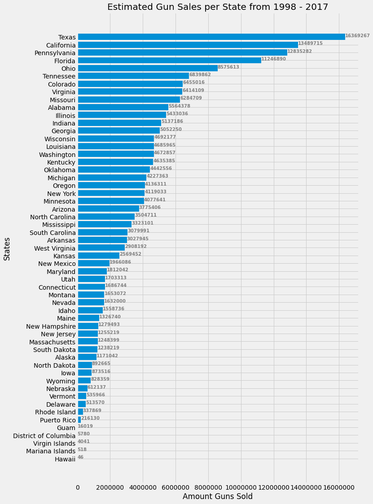

```python
import matplotlib.style as style
style.use('fivethirtyeight')
fig, ax = plt.subplots(figsize=(10,18))
ax.barh(df_st.loc[:,'state'], df_st.loc[:,'estimated_sales'].astype(int))

ax.ticklabel_format(axis = 'x', style='plain')

# Add annotation to bars
for i in ax.patches:
    ax.text(i.get_width()+500, i.get_y()+.4, str(round((i.get_width()), 2)), fontsize=10, fontweight='bold', color='grey')


plt.title('Estimated Gun Sales per State from 1998 - 2017')
plt.xlabel('Amount Guns Sold')
plt.ylabel('States')
plt.show();
```

> The top five states with the highest gun sales from 1998 - 2017 are 1. Texas, 2. California, 3. Pennsylvania, 4. Florida, 5. Ohio

```python
df_gun
```

|  | month | state | handgun | long_gun | multiple | private_sale_handgun | private_sale_long_gun | estimated_sales | estimated_pvt_sales |
| --- | --- | --- | --- | --- | --- | --- | --- | --- | --- |
| 0 | 2017-09-01 | Alabama | 5734.0 | 6320.0 | 317 | 9.0 | 16.0 | 13956.8 | 27.5 |
| 1 | 2017-09-01 | Alaska | 2320.0 | 2930.0 | 160 | 17.0 | 24.0 | 6127.0 | 45.1 |
| 2 | 2017-09-01 | Arizona | 11063.0 | 7946.0 | 631 | 38.0 | 12.0 | 22298.1 | 55.0 |
| 3 | 2017-09-01 | Arkansas | 4347.0 | 6063.0 | 366 | 13.0 | 23.0 | 12256.2 | 39.6 |
| 4 | 2017-09-01 | California | 37165.0 | 24581.0 | 0 | 0.0 | 0.0 | 67920.6 | 0.0 |
| ... | ... | ... | ... | ... | ... | ... | ... | ... | ... |
| 12480 | 1998-11-01 | Virginia | 14.0 | 2.0 | 8 | NaN | NaN | 35.2 | NaN |
| 12481 | 1998-11-01 | Washington | 65.0 | 286.0 | 8 | NaN | NaN | 403.7 | NaN |
| 12482 | 1998-11-01 | West Virginia | 149.0 | 251.0 | 5 | NaN | NaN | 451.0 | NaN |
| 12483 | 1998-11-01 | Wisconsin | 25.0 | 214.0 | 2 | NaN | NaN | 267.3 | NaN |
| 12484 | 1998-11-01 | Wyoming | 45.0 | 49.0 | 5 | NaN | NaN | 114.4 | NaN |

12485 rows × 9 columns

### Research Question 2: Are gun sales growing or declining?

For this question we need to drop the data from the year 2017 because it only report until september so the data is incomplete for that year.

```python
df = df_gun[df_gun.month.dt.year != 2017]
```

```python
df
```

|  | month | state | handgun | long_gun | multiple | private_sale_handgun | private_sale_long_gun | estimated_sales | estimated_pvt_sales |
| --- | --- | --- | --- | --- | --- | --- | --- | --- | --- |
| 495 | 2016-12-01 | Alabama | 13733.0 | 17519.0 | 533 | 2.0 | 2.0 | 35549.8 | 4.4 |
| 496 | 2016-12-01 | Alaska | 4087.0 | 3698.0 | 191 | 0.0 | 0.0 | 8983.7 | 0.0 |
| 497 | 2016-12-01 | Arizona | 18024.0 | 13785.0 | 703 | 2.0 | 2.0 | 36536.5 | 4.4 |
| 498 | 2016-12-01 | Arkansas | 9192.0 | 13433.0 | 385 | 2.0 | 7.0 | 25734.5 | 9.9 |
| 499 | 2016-12-01 | California | 63649.0 | 93224.0 | 0 | 0.0 | 0.0 | 172560.3 | 0.0 |
| ... | ... | ... | ... | ... | ... | ... | ... | ... | ... |
| 12480 | 1998-11-01 | Virginia | 14.0 | 2.0 | 8 | NaN | NaN | 35.2 | NaN |
| 12481 | 1998-11-01 | Washington | 65.0 | 286.0 | 8 | NaN | NaN | 403.7 | NaN |
| 12482 | 1998-11-01 | West Virginia | 149.0 | 251.0 | 5 | NaN | NaN | 451.0 | NaN |
| 12483 | 1998-11-01 | Wisconsin | 25.0 | 214.0 | 2 | NaN | NaN | 267.3 | NaN |
| 12484 | 1998-11-01 | Wyoming | 45.0 | 49.0 | 5 | NaN | NaN | 114.4 | NaN |

11990 rows × 9 columns

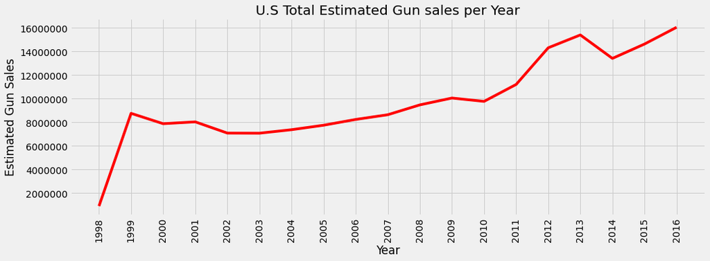

```python
results = df.groupby(df_gun.loc[:,'month'].dt.year).sum()
year = [year for year, df in df.groupby(df.loc[:,'month'].dt.year)]
plt.figure(figsize=(15,5))
plt.plot(year,results['estimated_sales'], color='red')
plt.ticklabel_format(axis = 'both', style='plain')
plt.title('U.S Total Estimated Gun sales per Year')
plt.xticks(year, rotation='vertical')
plt.ylabel('Estimated Gun Sales')
plt.xlabel('Year')
plt.show()
```

> The total gun sales are increasing overall, with a few dips however.

#### Reasearch Question 3: What are the characteristics of states with higher hand gun registrations and those with higher long gun purchases?

```python
cen_gun.head(3)
```

| state | handgun | long_gun | multiple | private_sale_handgun | private_sale_long_gun | estimated_sales | estimated_pvt_sales | total_pop_2016 | white_pop_2016_% | black_pop_2016_% | asian_pop_2016_% | hispanic_latino_pop_2016_% | high_scool_grad_2015_% | bachelors_degree_2015_% | labor_force_% | median_household_income_2015_$ | poverty_% |
| --- | --- | --- | --- | --- | --- | --- | --- | --- | --- | --- | --- | --- | --- | --- | --- | --- | --- |
| Alabama | 198428.5 | 149019.0 | 8663.0 | 55.0 | 56.5 | 401250.85 | 122.65 | 4863300.0 | 69.3 | 26.8 | 1.4 | 4.2 | 84.3 | 23.5 | 58.0 | 43623.0 | 17.1 |
| Alaska | 37288.5 | 36629.5 | 2278.0 | 24.5 | 37.5 | 86321.40 | 68.20 | 741894.0 | 66.1 | 3.8 | 6.3 | 7.0 | 92.1 | 28.0 | 67.7 | 72515.0 | 9.9 |
| Arizona | 157592.0 | 101071.5 | 7351.0 | 52.5 | 38.5 | 300702.05 | 100.10 | 6931071.0 | 83.3 | 4.9 | 3.4 | 30.9 | 86.0 | 27.5 | 59.3 | 50255.0 | 16.4 |

#### Question 3: What are the averages of the characteristics of states with higher long gun sales and higher handgun sales?

```python
df_hg = cen_gun.query('handgun > long_gun')
```

```python
df_lg = cen_gun.query('long_gun > handgun')
```

```python
df_lg.count()
```

```
handgun                           14
long_gun                          14
multiple                          14
private_sale_handgun              14
private_sale_long_gun             14
estimated_sales                   14
estimated_pvt_sales               14
total_pop_2016                    14
white_pop_2016_%                  14
black_pop_2016_%                  14
asian_pop_2016_%                  14
hispanic_latino_pop_2016_%        14
high_scool_grad_2015_%            14
bachelors_degree_2015_%           14
labor_force_%                     14
median_household_income_2015_$    14
poverty_%                         14
dtype: int64
```

```python
df_hg.count()
```

```
handgun                           35
long_gun                          35
multiple                          35
private_sale_handgun              35
private_sale_long_gun             35
estimated_sales                   35
estimated_pvt_sales               35
total_pop_2016                    35
white_pop_2016_%                  35
black_pop_2016_%                  35
asian_pop_2016_%                  35
hispanic_latino_pop_2016_%        35
high_scool_grad_2015_%            35
bachelors_degree_2015_%           35
labor_force_%                     35
median_household_income_2015_$    35
poverty_%                         35
dtype: int64
```

```python
df_lg.loc[:,'total_pop_2016':'poverty_%'].mean().round()
```

```
total_pop_2016                    4147779.0
white_pop_2016_%                       84.0
black_pop_2016_%                        8.0
asian_pop_2016_%                        3.0
hispanic_latino_pop_2016_%              8.0
high_scool_grad_2015_%                 90.0
bachelors_degree_2015_%                30.0
labor_force_%                          66.0
median_household_income_2015_$      54812.0
poverty_%                              13.0
dtype: float64
```

```python
df_hg.loc[:,'total_pop_2016':'poverty_%'].mean().round()
```

```
total_pop_2016                    7512825.0
white_pop_2016_%                       79.0
black_pop_2016_%                       13.0
asian_pop_2016_%                        4.0
hispanic_latino_pop_2016_%             13.0
high_scool_grad_2015_%                 87.0
bachelors_degree_2015_%                29.0
labor_force_%                          63.0
median_household_income_2015_$      53678.0
poverty_%                              14.0
dtype: float64
```

#### Question 4: What are the relationships between various census data to private gun sales and regular gun sales?

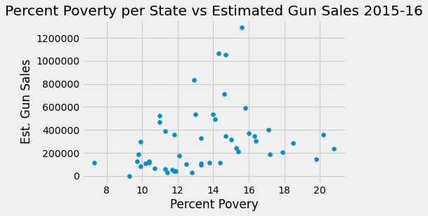

```python
plt.scatter(cen_gun.loc[:,'poverty_%'], cen_gun.loc[:,'estimated_sales'])
plt.ticklabel_format(axis = 'both', style='plain')
plt.xlabel('Percent Povery')
plt.ylabel('Est. Gun Sales')
plt.title('Percent Poverty per State vs Estimated Gun Sales 2015-16');
```

> Based on this scatter plot it seems that most gun sales are in states where poverty is between 12 - 16 % which is the midway point of poverty percent per state. My assumption was that states with more poverty had more gun sales but it seems that relationship doesnt exist.

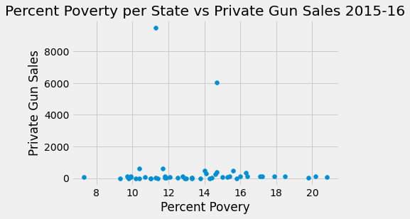

```python
plt.scatter(cen_gun.loc[:,'poverty_%'], cen_gun.loc[:,'estimated_pvt_sales'])
plt.ticklabel_format(axis = 'both', style='plain')
plt.xlabel('Percent Povery')
plt.ylabel('Private Gun Sales')
plt.title('Percent Poverty per State vs Private Gun Sales 2015-16');
```

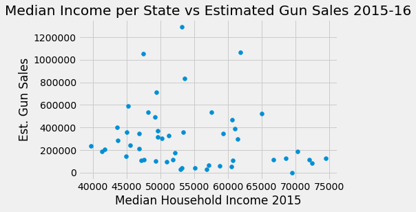

```python
plt.scatter(cen_gun.loc[:,'median_household_income_2015_$'], cen_gun.loc[:,'estimated_sales'])
plt.ticklabel_format(axis = 'both', style='plain')
plt.xlabel('Median Household Income 2015')
plt.ylabel('Est. Gun Sales')
plt.title('Median Income per State vs Estimated Gun Sales 2015-16');
```

> Here as well we see that more gun sales occur in states with income that is in the mid-range.

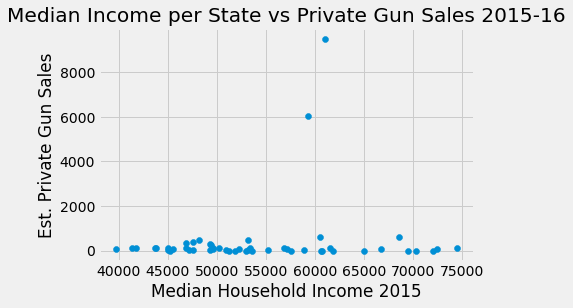

```python
plt.scatter(cen_gun.loc[:,'median_household_income_2015_$'], cen_gun.loc[:,'estimated_pvt_sales'])
plt.ticklabel_format(axis = 'both', style='plain')
plt.xlabel('Median Household Income 2015')
plt.ylabel('Est. Private Gun Sales')
plt.title('Median Income per State vs Private Gun Sales 2015-16');
```

> Most private gun sales seem to be around the same level regardless of household income, aside from two outlier states.

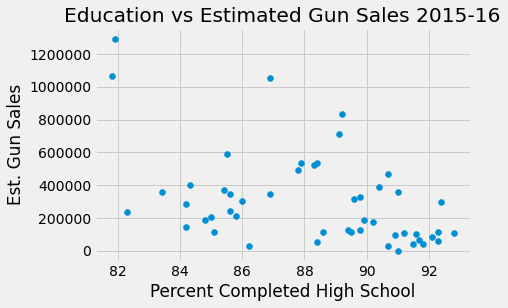

```python
plt.scatter(cen_gun.loc[:,'high_scool_grad_2015_%'], cen_gun.loc[:,'estimated_sales'])
plt.ticklabel_format(axis = 'both', style='plain')
plt.xlabel('Percent Completed High School')
plt.ylabel('Est. Gun Sales')
plt.title('Education vs Estimated Gun Sales 2015-16');
```

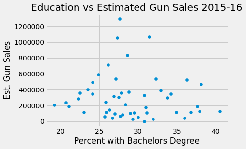

```python
plt.scatter(cen_gun.loc[:,'bachelors_degree_2015_%'], cen_gun.loc[:,'estimated_sales'])
plt.ticklabel_format(axis = 'both', style='plain')
plt.xlabel('Percent with Bachelors Degree')
plt.ylabel('Est. Gun Sales')
plt.title('Education vs Estimated Gun Sales 2015-16');
```

> Similar to the other charts most of concentration of points is in the middle, as well as the highest estimated gun sales. It seems that in states with around 30% completion of Bachelors degrees have the highest estimated gun sales. 30% is about the mid point in this graph.

## Conclusions:

#### Question 1: Which states have the highest total gun sales?

> Texas 16,369,267 , California 13,489,716 , Pennsylvania 12,835,283 , Florida 11,246,891, Ohio 8,575,613

```python
df_gun.groupby('state')['estimated_sales'].sum().sort_values(ascending=False).head()
```

```
state
Texas           16369267.2
California      13489715.8
Pennsylvania    12835282.9
Florida         11246890.6
Ohio             8575613.2
Name: estimated_sales, dtype: float64
```

#### Question 2: Are gun sales growing or declining?

> According to the graph we plotted it is evident that gun sales in the U.S have been on the rise significantly since 1998 up to 2017. There have been some years when there have been decreases such as from 1999 - 2000 , 2001 - 2002, 2009 - 2010, 2013 - 2014. But those dips have all been modest compared to the inclines, and as of the last data point , we are at all time highs in U.S estimated gun sales. U.S gun sales are growing.

### Question 3: What are the characteristics of states with higher long gun sales and higher handgun sales?

>

> Higher long gun sales:

```python
total_pop_2016                    4147779.0
white_pop_2016_%                       84.0
black_pop_2016_%                        8.0
asian_pop_2016_%                        3.0
hispanic_latino_pop_2016_%              8.0
high_scool_grad_2015_%                 90.0
bachelors_degree_2015_%                30.0
labor_force_%                          66.0
median_household_income_2015_$      54812.0
poverty_%                              13.0
```

> Higher hand gun sales:

```python
total_pop_2016                    7512825.0
white_pop_2016_%                       79.0
black_pop_2016_%                       13.0
asian_pop_2016_%                        4.0
hispanic_latino_pop_2016_%             13.0
high_scool_grad_2015_%                 87.0
bachelors_degree_2015_%                29.0
labor_force_%                          63.0
median_household_income_2015_$      53678.0
poverty_%                              14.0
```